# Praktikum 6 dan 7: Pendugaan Parameter, Diagnostik Model, dan Peramalan

Aida Darajati

2023-10-13

## Packages

```r
library(ggplot2)
library(tsibble)
library(tseries)
library(MASS)
library(forecast)
library(TSA)
library(TTR)
library(aTSA)
library(graphics)
```

# Impor Data

```r
#install.packages("rio") #install jika belum ada
library(rio)
datashanghai <- import("https://raw.githubusercontent.com/aidara11/mpdw/main/Data/Data_Shanghai.csv")
head(datashanghai)
```

```
##         Date Average price
## 1 2002-01-01         14735
## 2 2002-02-01         14057
## 3 2002-03-01         14662
## 4 2002-04-01         16334
## 5 2002-05-01         18357
## 6 2002-06-01         20178
```

```r
datashanghai.ts <- ts(datashanghai$`Average price`)
```

### Eksplorasi Data

#### Plot Data Penuh

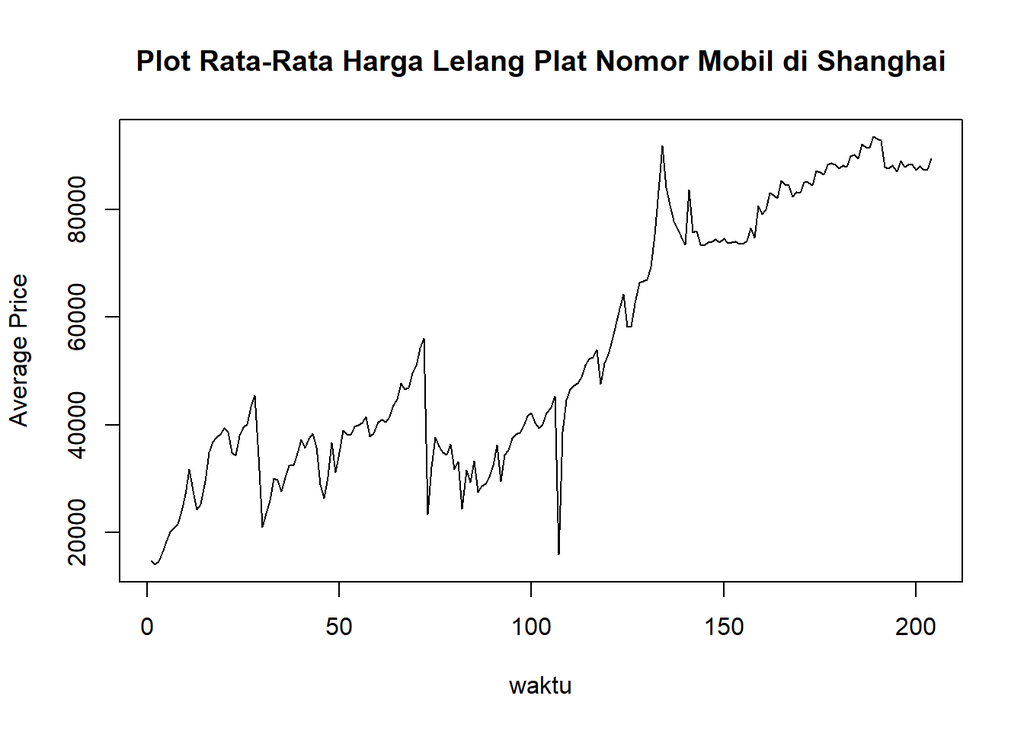

```r
plot.ts(datashanghai.ts, lty=1, xlab="waktu", ylab="Average Price", main="Plot Rata-Rata Harga Lelang Plat Nomor Mobil di Shanghai")
```

Berdasarkan plot data deret waktu, terlihat bahwa data cenderung memiliki trend yang naik. Berdasarkan pola data, pembagian data latih dan data uji ditetapkan dengan proporsi 74%:26%.

#### Plot Data Latih

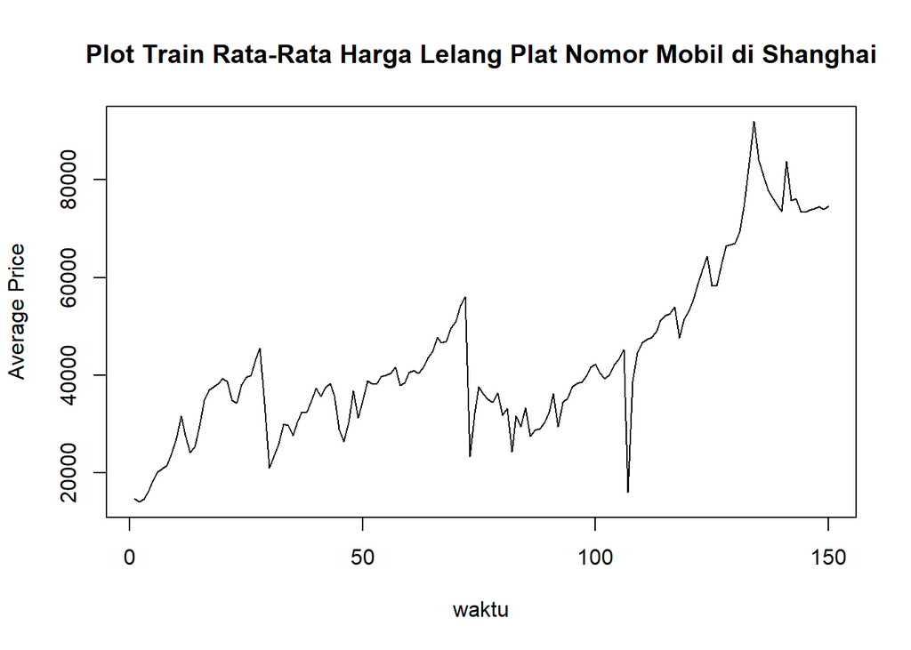

```r
lelangtrain <- datashanghai.ts[1:150]
train.ts <- ts(lelangtrain)
plot.ts(train.ts, lty=1, xlab="waktu", ylab="Average Price", main="Plot Train Rata-Rata Harga Lelang Plat Nomor Mobil di Shanghai")
```

Berdasarkan plot data deret waktu pada data latih, terlihat bahwa data cenderung memiliki trend yang naik dan cenderung tidak bergerak pada nilai tengah tertentu. Hal ini mengindikasikan bahwa data tidak stasioner dalam rataan.

#### Plot Data Uji

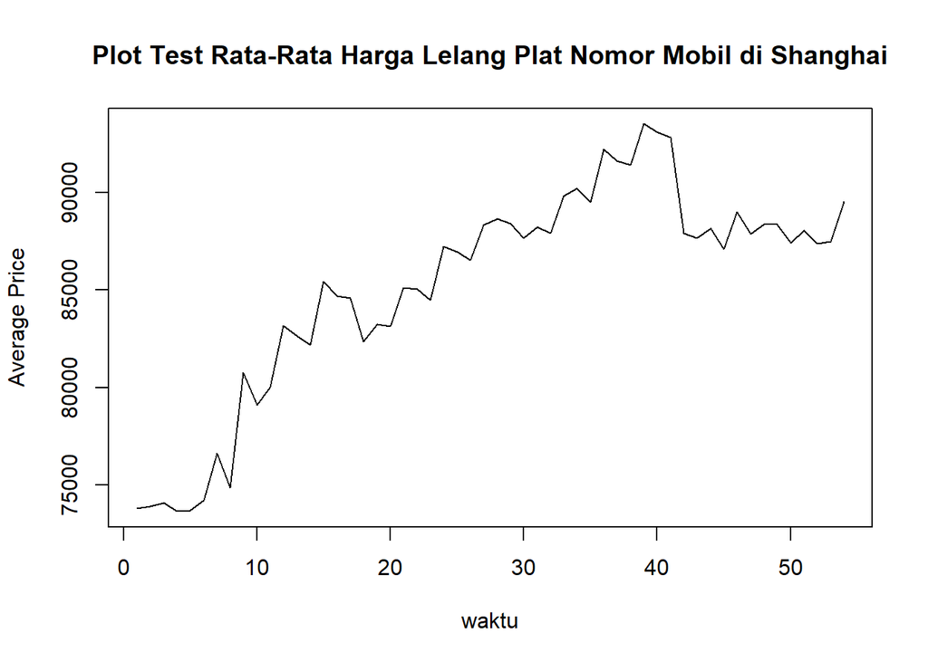

```r
lelangtest <- datashanghai.ts[151:204]
test.ts <- ts(lelangtest)
plot.ts(test.ts, lty=1, xlab="waktu", ylab="Average Price", main="Plot Test Rata-Rata Harga Lelang Plat Nomor Mobil di Shanghai")
```

Berdasarkan plot data deret waktu pada data uji, terlihat bahwa data cenderung memiliki trend yang naik dan cenderung tidak bergerak pada nilai tengah tertentu. Hal ini mengindikasikan bahwa data uji tidak stasioner dalam rataan.

### Uji Stasioneritas Data

#### Plot ACF

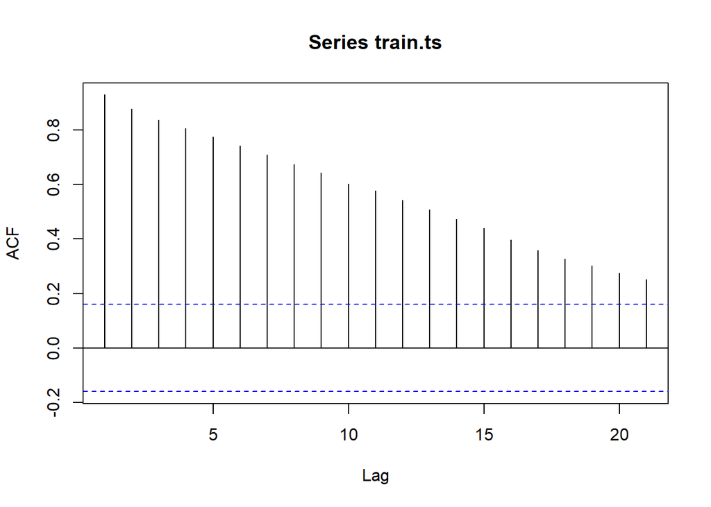

```r
acf(train.ts)
```

Berdasarkan plot ACF, terlihat bahwa plot ACF data train menurun secara perlahan (*tails of slowly*). Hal ini juga menjadi indikasi bahwa data tidak stasioner dalam rataan

#### Uji ADF

```r
tseries::adf.test(train.ts)
```

```
##
##  Augmented Dickey-Fuller Test
##
## data:  train.ts
## Dickey-Fuller = -1.7566, Lag order = 5, p-value = 0.6778
## alternative hypothesis: stationary
```

$H_0$ : Data tidak stasioner dalam rataan

$H_1$ : Data stasioner dalam rataan

Berdasarkan uji ADF tersebut, didapat *p-value* sebesar 0.6778 yang lebih besar dari taraf nyata 5% sehingga tak tolak $H_0$ dan menandakan bahwa data train tidak stasioner dalam rataan. Hal ini sesuai dengan hasil eksplorasi menggunakan plot time series dan plot ACF, sehingga ketidakstasioneran model kedepannya harus ditangani.

#### Plot Box-Cox

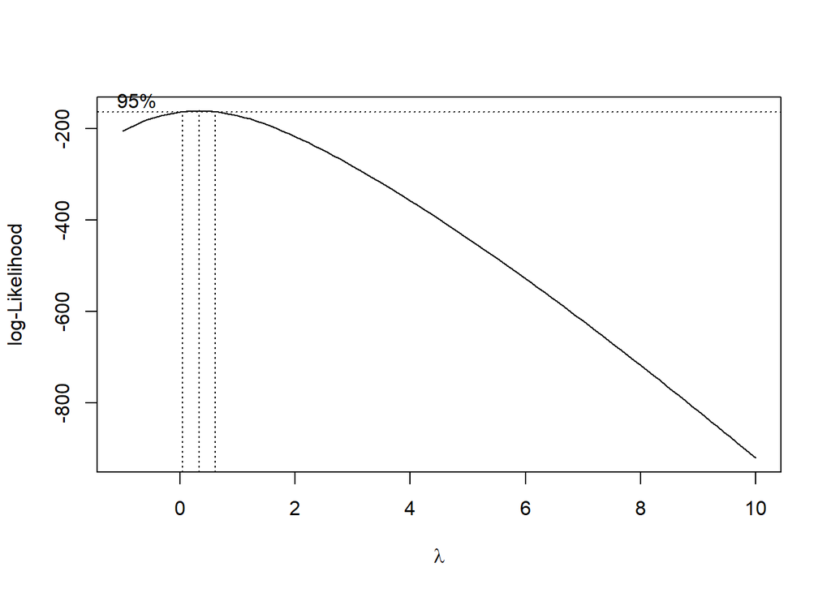

```r
index <- seq(1:150)
bc = boxcox(train.ts~index, lambda = seq(-1, 10, by=1))
```

```r
#Nilai Rounded Lambda
lambda <- bc$x[which.max(bc$y)]
lambda
```

```
## [1] 0.3333333
```

```r
#SK
bc$x[bc$y > max(bc$y) - 1/2 * qchisq(.95,1)]
```

```
## [1] 0.1111111 0.2222222 0.3333333 0.4444444 0.5555556
```

Plot Boxcox menunjukkan nilai *rounded value* ($\lambda$) optimum sebesar **0.3333333** dan pada selang kepercayaan 95% nilai memiliki batas bawah **0.1111111** dan batas atas **0.5555556**. Selang tersebut tidak memuat nilai satu sehingga dapat dikatakan bahwa data train tidak stasioner dalam ragam.

### Penanganan Ketidakstasioneran Data

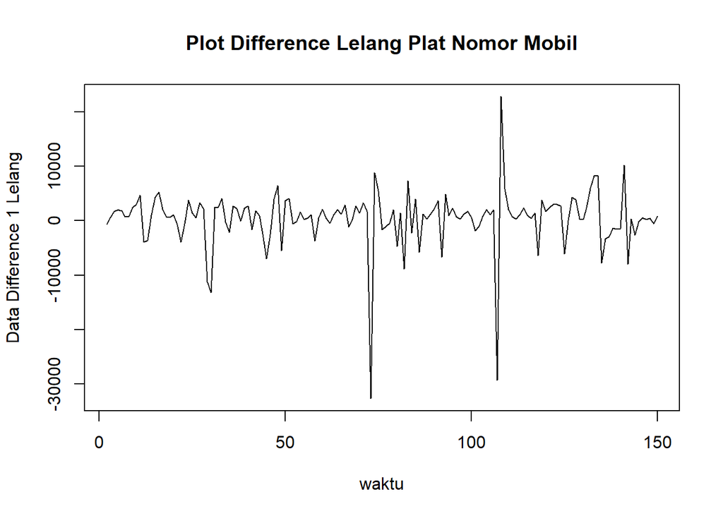

```r
train.diff <- diff(train.ts,differences = 1)
plot.ts(train.diff, lty=1, xlab="waktu", ylab="Data Difference 1 Lelang", main="Plot Difference Lelang Plat Nomor Mobil")
```

Berdasarkan plot data deret waktu, terlihat bahwa data sudah stasioner dalam rataan ditandai dengan data bergerak pada nilai tengah tertentu (tidak terdapat trend ataupun musiman pada data)

#### Plot ACF

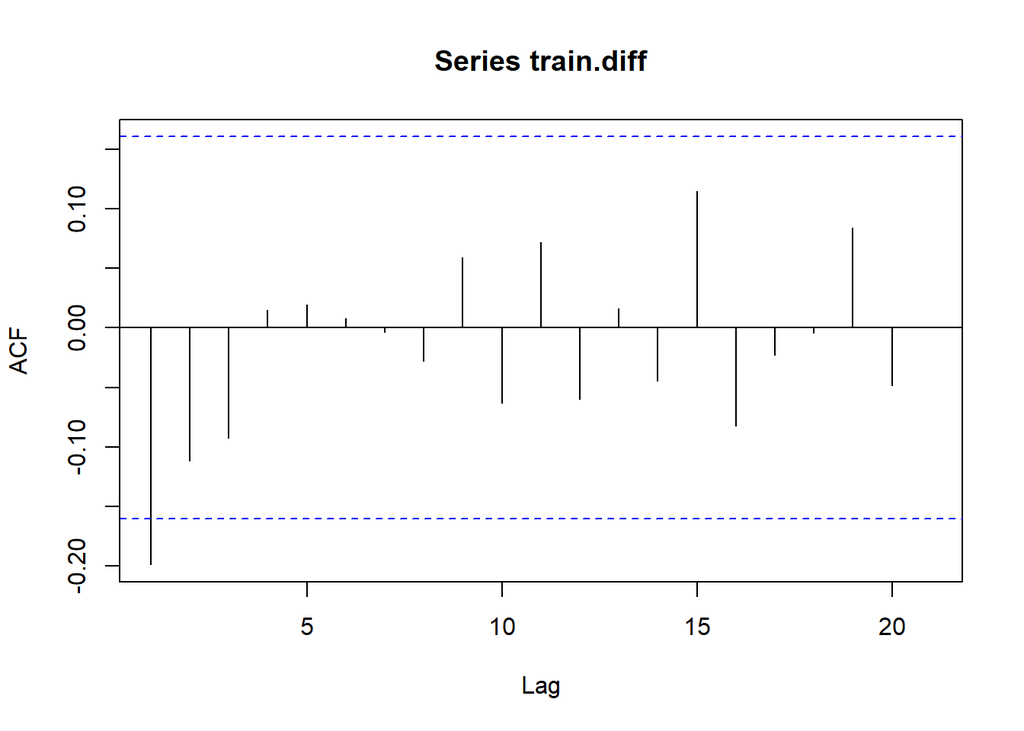

```r
acf(train.diff)
```

Berdasarkan plot tersebut, terlihat bahwa plot ACF cuts off pada lag ke 1. Hal ini menandakan data sudah stasioner dalam rataan dan ketidakstasioneran data telah berhasil tertangani.

#### Uji ADF

```r
tseries::adf.test(train.diff)
```

```
##
##  Augmented Dickey-Fuller Test
##
## data:  train.diff
## Dickey-Fuller = -5.8793, Lag order = 5, p-value = 0.01
## alternative hypothesis: stationary
```

$H_0$ : Data tidak stasioner dalam rataan

$H_1$ : Data stasioner dalam rataan

Berdasarkan uji ADF tersebut, didapat *p-value* sebesar 0.01 yang lebih kecil dari taraf nyata 5% sehingga tolak $H_0$ atau data stasioner dalam rataan. Hal ini sesuai dengan hasil eksplorasi menggunakan plot time series dan plot ACF, sehingga dalam hal ini ketidakstasioneran data sudah berhasil ditangani dan dapat dilanjutkan ke pemodelan.

### Identifikasi Model

#### Plot ACF

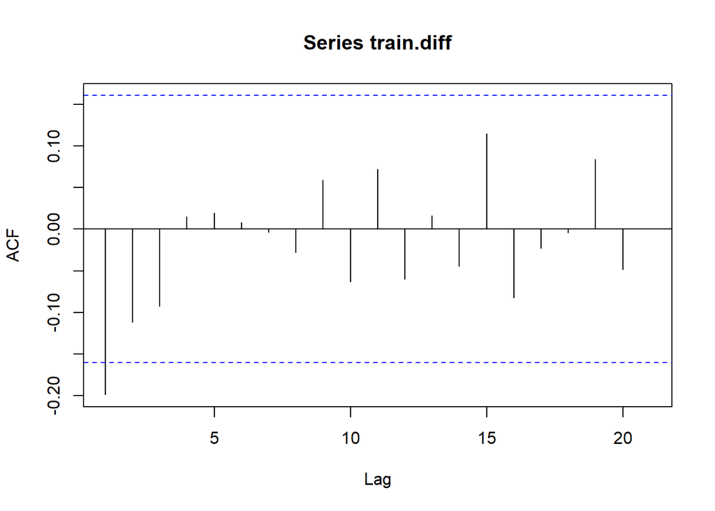

```r
acf(train.diff)
```

Berdasarkan plot tersebut, terlihat bahwa plot ACF cenderung *cuts off* pada lag ke 1, sehingga jika plot PACF dianggap *tails of*, maka model tentatifnya adalah ARIMA(0,1,1).

#### Plot PACF

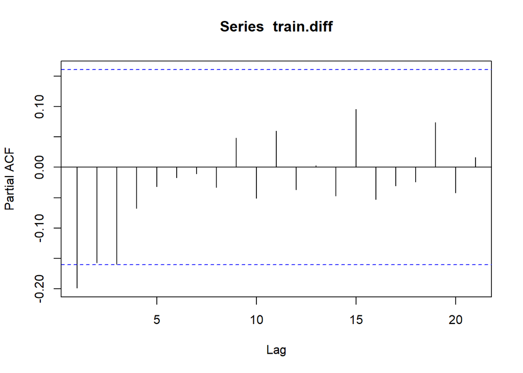

```r
pacf(train.diff)
```

Berdasarkan plot tersebut, terlihat bahwa plot PACF cenderung *cuts off* pada lag ke 1, sehingga jika plot ACF dianggap *tails of*, maka model tentatifnya adalah ARIMA(1,1,0).

Jika baik plot ACF maupun plot PACF keduanya dianggap tails of, maka model yang terbentuk adalah ARIMA(1,1,1)

#### Plot EACF

```r
eacf(train.diff)
```

```
## AR/MA
##   0 1 2 3 4 5 6 7 8 9 10 11 12 13
## 0 x o o o o o o o o o o  o  o  o
## 1 x o o o o o o o o o o  o  o  o
## 2 x x o o o o o o o o o  o  o  o
## 3 x o o o o o o o o o o  o  o  o
## 4 x o o o o o o o o o o  o  o  o
## 5 x o o o o o o o o o o  o  o  o
## 6 x o o o o o o o o o o  o  o  o
## 7 x x o o o o o o o o o  o  o  o
```

Identifikasi model menggunakan plot EACF dilakukan dengan melihat ujung segitiga pada pola segitiga nol. Dalam hal ini model tentatif yang terbentuk adalah ARIMA(0,1,2), ARIMA(0,1,3), ARIMA(1,1,2), ARIMA(1,1,3), dan ARIMA(2,1,2).

### Pendugaan Parameter Model Tentatif

#### ARIMA(0,1,1)

```r
model1.da=Arima(train.diff, order=c(0,1,1),method="ML")
summary(model1.da)
```

```
## Series: train.diff
## ARIMA(0,1,1)
##
## Coefficients:
##           ma1
##       -1.0000
## s.e.   0.0181
##
## sigma^2 = 29292160:  log likelihood = -1484.27
## AIC=2972.55   AICc=2972.63   BIC=2978.54
##
## Training set error measures:
##                     ME     RMSE      MAE      MPE     MAPE      MASE      ACF1
## Training set -74.33536 5375.777 2992.665 79.95761 99.63757 0.7011313 -0.198474
```

```r
lmtest::coeftest(model1.da)
```

```
##
## z test of coefficients:
##
##     Estimate Std. Error z value  Pr(>|z|)
## ma1 -1.00000    0.01809 -55.279 < 2.2e-16 ***
## ---
## Signif. codes:  0 '***' 0.001 '**' 0.01 '*' 0.05 '.' 0.1 ' ' 1
```

Didapatkan nilai AIC sebesar 2972.55 dan seluruh parameter signifikan.

#### ARIMA(1,1,0)

```r
model2.da=Arima(train.diff, order=c(1,1,0),method="ML")
summary(model2.da) #AIC=4917.41
```

```
## Series: train.diff
## ARIMA(1,1,0)
##
## Coefficients:
##           ar1
##       -0.5328
## s.e.   0.0690
##
## sigma^2 = 50016004:  log likelihood = -1521.53
## AIC=3047.06   AICc=3047.14   BIC=3053.05
##
## Training set error measures:
##                    ME     RMSE      MAE      MPE     MAPE      MASE       ACF1
## Training set 8.737345 7024.575 4000.001 101.7698 218.4503 0.9371331 -0.1974179
```

```r
lmtest::coeftest(model2.da) #seluruh parameter signifikan
```

```
##
## z test of coefficients:
##
##      Estimate Std. Error z value  Pr(>|z|)
## ar1 -0.532818   0.069002 -7.7218 1.147e-14 ***
## ---
## Signif. codes:  0 '***' 0.001 '**' 0.01 '*' 0.05 '.' 0.1 ' ' 1
```

Didapatkan nilai AIC sebesar 3047.06 dan seluruh parameter signifikan.

#### ARIMA(1,1,1)

```r
model3.da=Arima(train.diff, order=c(1,1,1),method="ML")
summary(model3.da)
```

```
## Series: train.diff
## ARIMA(1,1,1)
##
## Coefficients:
##           ar1     ma1
##       -0.1922  -1.000
## s.e.   0.0805   0.019
##
## sigma^2 = 28328190:  log likelihood = -1481.48
## AIC=2968.97   AICc=2969.14   BIC=2977.96
##
## Training set error measures:
##                     ME     RMSE      MAE      MPE     MAPE      MASE
## Training set -98.27522 5268.569 3020.318 61.96714 128.3851 0.7076098
##                     ACF1
## Training set -0.03655965
```

```r
lmtest::coeftest(model3.da)
```

```
##
## z test of coefficients:
##
##      Estimate Std. Error  z value Pr(>|z|)
## ar1 -0.192151   0.080482  -2.3875  0.01696 *
## ma1 -1.000000   0.019013 -52.5949  < 2e-16 ***
## ---
## Signif. codes:  0 '***' 0.001 '**' 0.01 '*' 0.05 '.' 0.1 ' ' 1
```

Didapatkan nilai AIC sebesar 2968.97 dan seluruh parameter signifikan.

#### ARIMA(0,1,2)

```r
model4.da=Arima(train.diff, order=c(0,1,2),method="ML")
summary(model4.da)
```

```
## Series: train.diff
## ARIMA(0,1,2)
##
## Coefficients:
##           ma1     ma2
##       -1.2929  0.2929
## s.e.   0.1015  0.0996
##
## sigma^2 = 27746631:  log likelihood = -1480.14
## AIC=2966.29   AICc=2966.46   BIC=2975.28
##
## Training set error measures:
##                     ME     RMSE      MAE      MPE     MAPE      MASE       ACF1
## Training set -125.6573 5214.209 3040.532 59.35305 142.9338 0.7123456 0.03924379
```

```r
lmtest::coeftest(model4.da)
```

```
##
## z test of coefficients:
##
##      Estimate Std. Error z value  Pr(>|z|)
## ma1 -1.292936   0.101519 -12.736 < 2.2e-16 ***
## ma2  0.292939   0.099606   2.941  0.003272 **
## ---
## Signif. codes:  0 '***' 0.001 '**' 0.01 '*' 0.05 '.' 0.1 ' ' 1
```

Didapatkan nilai AIC sebesar 2966.29 dan seluruh parameter signifikan.

#### ARIMA(0,1,3)

```r
model5.da=Arima(train.diff, order=c(0,1,3),method="ML")
summary(model5.da)
```

```
## Series: train.diff
## ARIMA(0,1,3)
##
## Coefficients:
##           ma1     ma2     ma3
##       -1.2723  0.1213  0.1509
## s.e.   0.0838  0.1211  0.0772
##
## sigma^2 = 27164638:  log likelihood = -1478.3
## AIC=2964.6   AICc=2964.88   BIC=2976.59
##
## Training set error measures:
##                     ME     RMSE      MAE      MPE     MAPE     MASE      ACF1
## Training set -157.0924 5141.535 3001.593 81.10624 137.6461 0.703223 0.0023667
```

```r
lmtest::coeftest(model5.da)
```

```
##
## z test of coefficients:
##
##      Estimate Std. Error  z value Pr(>|z|)
## ma1 -1.272256   0.083775 -15.1866  < 2e-16 ***
## ma2  0.121345   0.121136   1.0017  0.31648
## ma3  0.150912   0.077205   1.9547  0.05062 .
## ---
## Signif. codes:  0 '***' 0.001 '**' 0.01 '*' 0.05 '.' 0.1 ' ' 1
```

Didapatkan nilai AIC sebesar 2964.6 dan terdapat parameter ma2 yang tidak signifikan.

#### ARIMA(1,1,2)

```r
model6.da=Arima(train.diff, order=c(1,1,2),method="ML")
summary(model6.da)
```

```
## Series: train.diff
## ARIMA(1,1,2)
##
## Coefficients:
##          ar1      ma1     ma2
##       0.4116  -1.6827  0.6827
## s.e.  0.1738   0.1409  0.1397
##
## sigma^2 = 27098375:  log likelihood = -1478.17
## AIC=2964.34   AICc=2964.62   BIC=2976.32
##
## Training set error measures:
##                     ME     RMSE      MAE     MPE     MAPE      MASE        ACF1
## Training set -156.5816 5135.261 3014.878 87.0982 139.2806 0.7063355 0.003687962
```

```r
lmtest::coeftest(model6.da)
```

```
##
## z test of coefficients:
##
##     Estimate Std. Error  z value  Pr(>|z|)
## ar1  0.41156    0.17383   2.3676    0.0179 *
## ma1 -1.68267    0.14095 -11.9382 < 2.2e-16 ***
## ma2  0.68274    0.13967   4.8882 1.018e-06 ***
## ---
## Signif. codes:  0 '***' 0.001 '**' 0.01 '*' 0.05 '.' 0.1 ' ' 1
```

Didapatkan nilai AIC sebesar 2964.34 dan seluruh parameter signifikan.

#### ARIMA(1,1,3)

```r
model7.da=Arima(train.diff, order=c(1,1,3),method="ML")
summary(model7.da)
```

```
## Series: train.diff
## ARIMA(1,1,3)
##
## Coefficients:
##          ar1      ma1     ma2     ma3
##       0.2690  -1.5310  0.4599  0.0711
## s.e.  0.3593   0.3591  0.4926  0.1457
##
## sigma^2 = 27242906:  log likelihood = -1478.06
## AIC=2966.12   AICc=2966.54   BIC=2981.1
##
## Training set error measures:
##                     ME     RMSE      MAE      MPE     MAPE      MASE
## Training set -159.6277 5131.151 3004.562 88.28964 136.5091 0.7039186
##                      ACF1
## Training set -0.007376613
```

```r
lmtest::coeftest(model7.da)
```

```
##
## z test of coefficients:
##
##      Estimate Std. Error z value  Pr(>|z|)
## ar1  0.269050   0.359323  0.7488    0.4540
## ma1 -1.530951   0.359141 -4.2628 2.019e-05 ***
## ma2  0.459855   0.492640  0.9335    0.3506
## ma3  0.071104   0.145654  0.4882    0.6254
## ---
## Signif. codes:  0 '***' 0.001 '**' 0.01 '*' 0.05 '.' 0.1 ' ' 1
```

Didapatkan nilai AIC sebesar 2966.12 dan tidak semua parameter signifikan.

#### ARIMA(2,1,2)

```r
model8.da=Arima(train.diff, order=c(2,1,2),method="ML")
summary(model8.da)
```

```
## Series: train.diff
## ARIMA(2,1,2)
##
## Coefficients:
##          ar1      ar2      ma1     ma2
##       0.3531  -0.0595  -1.6120  0.6120
## s.e.  0.2151   0.1064   0.2059  0.2049
##
## sigma^2 = 27230266:  log likelihood = -1478.02
## AIC=2966.04   AICc=2966.46   BIC=2981.02
##
## Training set error measures:
##                     ME     RMSE      MAE      MPE   MAPE      MASE        ACF1
## Training set -160.5984 5129.961 3001.053 88.50719 136.15 0.7030964 -0.01094277
```

```r
lmtest::coeftest(model8.da)
```

```
##
## z test of coefficients:
##
##      Estimate Std. Error z value  Pr(>|z|)
## ar1  0.353063   0.215084  1.6415  0.100691
## ar2 -0.059536   0.106426 -0.5594  0.575880
## ma1 -1.611994   0.205887 -7.8295 4.897e-15 ***
## ma2  0.611996   0.204914  2.9866  0.002821 **
## ---
## Signif. codes:  0 '***' 0.001 '**' 0.01 '*' 0.05 '.' 0.1 ' ' 1
```

Didapatkan nilai AIC sebesar 2966.04 dan terdapat parameter yang tidak signifikan.

Berdasarkan pendugaan parameter di atas, nilai AIC terkecil 2964.34 dimiliki oleh model ARIMA(1,1,2) dan parameter model ARIMA(1,1,2) juga seluruhnya signifikan sehingga model yang dipilih adalah model ARIMA(1,1,2).

### Analisis Sisaan

Model terbaik hasil identifikasi kemudian dicek asumsi sisaannya. Sisaan model ARIMA harus memenuhi asumsi normalitas, kebebasan sisaan, dan kehomogenan ragam. Diagnostik model dilakukan secara eksplorasi dan uji formal.

#### Eksplorasi Sisaan

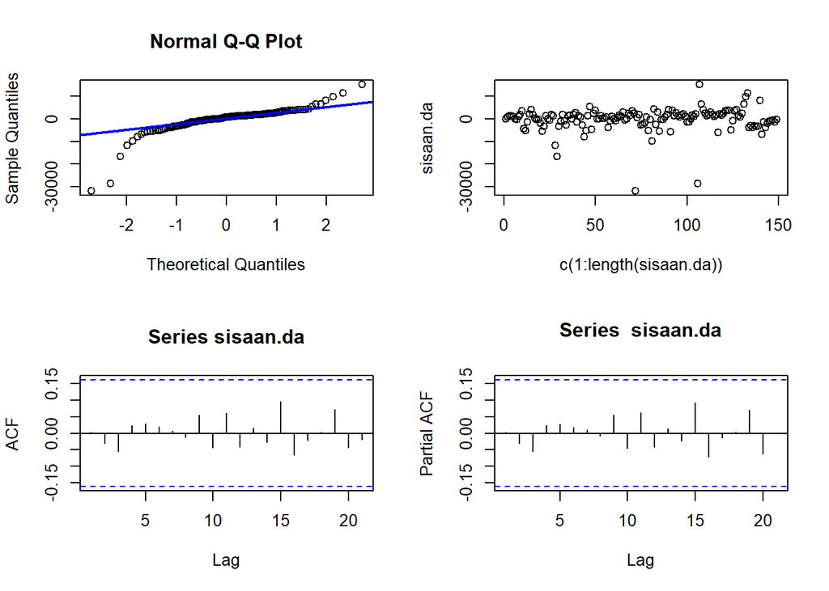

```r
#Eksplorasi
sisaan.da <- model6.da$residuals
par(mfrow=c(2,2))
qqnorm(sisaan.da)
qqline(sisaan.da, col = "blue", lwd = 2)
plot(c(1:length(sisaan.da)),sisaan.da)
acf(sisaan.da)
pacf(sisaan.da)
```

```r
par(mfrow = c(1,1))
```

Berdasarkan plot kuantil-kuantil normal, secara eksplorasi ditunjukkan sisaan tidak menyebar normal ditandai dengan titik titik yang cenderung tidak mengikuti garis $45^{\circ}$. Kemudian dapat dilihat juga lebar pita sisaan yang cenderung sama menandakan bahwa sisaan memiliki ragam yang homogen. Plot ACF dan PACF sisaan ARIMA(1,1,2) juga tidak signifikan pada 20 lag awal yang menandakan saling bebas. Kondisi ini akan diuji lebih lanjut dengan uji formal.

#### Uji Formal

```r
#1) Sisaan Menyebar Normal
ks.test(sisaan.da,"pnorm")  #tak tolak H0 > sisaan menyebar normal
```

```
##
##  Asymptotic one-sample Kolmogorov-Smirnov test
##
## data:  sisaan.da
## D = 0.58389, p-value < 2.2e-16
## alternative hypothesis: two-sided
```

Selain dengan eksplorasi, asumsi tersebut dapat diuji menggunakan uji formal. Pada tahapan ini uji formal yang digunakan untuk normalitas adalah uji Kolmogorov-Smirnov (KS). Hipotesis pada uji KS adalah sebagai berikut.

$H_0$ : Sisaan menyebar normal

$H_1$ : Sisaan tidak menyebar normal

Berdasarkan uji KS tersebut, didapat *p-value* sebesar 2.2e-16 yang kurang dari taraf nyata 5% sehingga tolak $H_0$ dan menandakan bahwa sisaan tidak menyebar normal. Hal ini sesuai dengan hasil eksplorasi menggunakan plot kuantil-kuantil normal.

```r
#2) Sisaan saling bebas/tidak ada autokorelasi
Box.test(sisaan.da, type = "Ljung")  #tak tolak H0 > sisaan saling bebas
```

```
##
##  Box-Ljung test
##
## data:  sisaan.da
## X-squared = 0.0020676, df = 1, p-value = 0.9637
```

Selanjutnya akan dilakukan uji formal untuk kebebasan sisaan menggunakan uji Ljung-Box. Hipotesis yang digunakan adalah sebagai berikut.

$H_0$ : Sisaan saling bebas

$H_1$ : Sisaan tidak tidak saling bebas

Berdasarkan uji Ljung-Box tersebut, didapat *p-value* sebesar 0.9637 yang lebih besar dari taraf nyata 5% sehingga tak tolak $H_0$ dan menandakan bahwa sisaan saling bebas. Hal ini sesuai dengan hasil eksplorasi menggunakan plot ACF dan PACF.

```r
#3) Sisaan homogen
Box.test((sisaan.da)^2, type = "Ljung")  #tak tolak H0 > sisaan homogen
```

```
##
##  Box-Ljung test
##
## data:  (sisaan.da)^2
## X-squared = 1.5258, df = 1, p-value = 0.2167
```

Hipotesis yang digunakan untuk uji kehomogenan ragam adalah sebagai berikut.

$H_0$ : Ragam sisaan homogen

$H_1$ : Ragam sisaan tidak homogen

Berdasarkan uji Ljung-Box terhadap sisaan kuadrat tersebut, didapat *p-value* sebesar 0.2167 yang lebih dari taraf nyata 5% sehingga tak tolak $H_0$ dan menandakan bahwa ragam sisaan homogen.

```r
#4) Nilai tengah sisaan sama dengan nol
t.test(sisaan.da, mu = 0, conf.level = 0.95)  #tak tolak h0 > nilai tengah sisaan sama dengan 0
```

```
##
##  One Sample t-test
##
## data:  sisaan.da
## t = -0.37112, df = 148, p-value = 0.7111
## alternative hypothesis: true mean is not equal to 0
## 95 percent confidence interval:
##  -990.3463  677.1831
## sample estimates:
## mean of x
## -156.5816
```

Terakhir, dengan uji-t, akan dicek apakah nilai tengah sisaan sama dengan nol. Hipotesis yang diujikan sebagai berikut.

$H_0$ : nilai tengah sisaan sama dengan 0

$H_1$ : nilai tengah sisaan tidak sama dengan 0

Berdasarkan uji-ttersebut, didapat *p-value* sebesar 0.7111 yang lebih besar dari taraf nyata 5% sehingga tak tolak $H_0$ dan menandakan bahwa nilai tengah sisaan sama dengan nol.

### Peramalan

Peramalan dilakukan menggunakan fungsi `forecast()` . Contoh peramalan berikut ini dilakukan untuk 54 hari ke depan.

```r
#---FORECAST---#
ramalan.da <- forecast::forecast(model6.da, h = 54)
ramalan.da
```

```
##     Point Forecast     Lo 80    Hi 80      Lo 95    Hi 95
## 151       653.7737 -6039.564 7347.112  -9582.804 10890.35
## 152       505.9309 -6417.484 7429.345 -10082.518 11094.38
## 153       445.0850 -6514.997 7405.167 -10199.441 11089.61
## 154       420.0434 -6545.593 7385.679 -10232.977 11073.06
## 155       409.7374 -6556.577 7376.051 -10244.320 11063.80
## 156       405.4958 -6560.825 7371.817 -10248.573 11059.56
## 157       403.7502 -6562.527 7370.028 -10250.252 11057.75
## 158       403.0318 -6563.220 7369.284 -10250.931 11056.99
## 159       402.7361 -6563.504 7368.976 -10251.209 11056.68
## 160       402.6144 -6563.621 7368.850 -10251.323 11056.55
## 161       402.5643 -6563.669 7368.797 -10251.370 11056.50
## 162       402.5437 -6563.689 7368.776 -10251.389 11056.48
## 163       402.5352 -6563.697 7368.767 -10251.397 11056.47
## 164       402.5317 -6563.700 7368.764 -10251.401 11056.46
```

[output cut: 40 more lines]

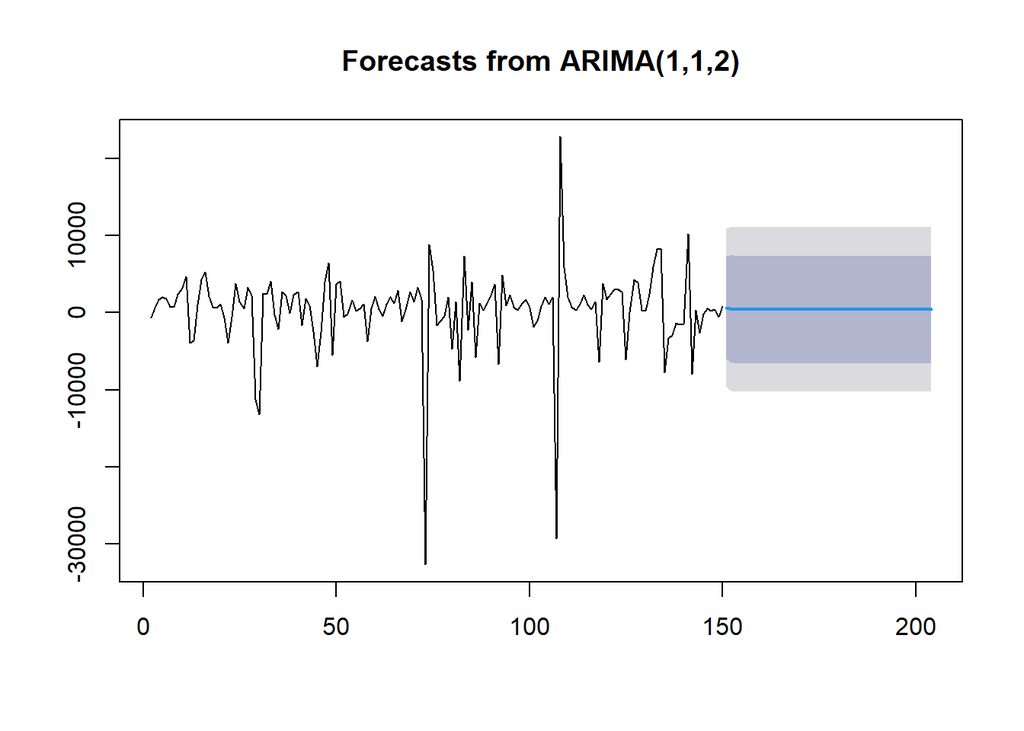

```r
data.ramalan.da <- ramalan.da$mean
plot(ramalan.da)
```

Berdasarkan hasil plot ramalan di atas, dapat dilihat bahwa ramalan ARIMA(1,1,2) cenderung stabil hingga akhir periode. Selanjutnya, dapat dicari nilai akurasi antara hasil ramalan dengan data uji sebagai berikut.

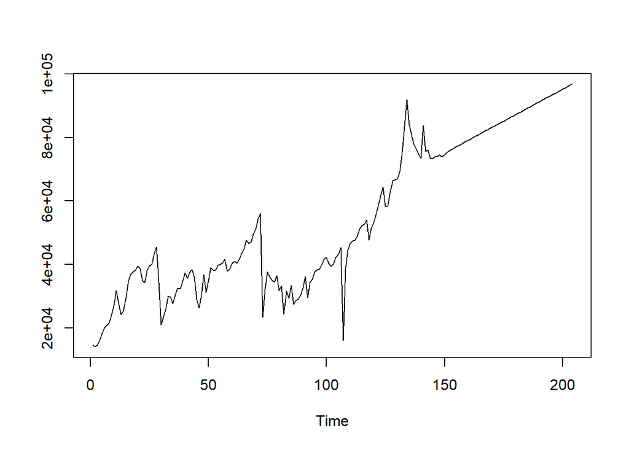

```r
pt_1 <- train.ts[150] #nilai akhir data latih
hasil.forc.Diff <- data.ramalan.da
hasil <- diffinv(hasil.forc.Diff, differences = 1) + pt_1
#has.1 sama hasilnta dengan: cumsum(c(pt_1,hasil.forc.Diff))
ts.plot(train.ts,hasil)
```

Dapat dilihat bahwa rata-rata harga lelang plat nomor mobil di shanghai diramalkan akan terus naik setiap periodenya.

```r
perbandingan.da<-matrix(data=c(head(test.ts, n=54), hasil[-1]),
                     nrow = 54, ncol = 2)
colnames(perbandingan.da)<-c("Aktual","Hasil Forecast")
perbandingan.da
```

```
##       Aktual Hasil Forecast
##  [1,]  73785       75333.77
##  [2,]  73875       75839.70
##  [3,]  74075       76284.79
##  [4,]  73633       76704.83
##  [5,]  73687       77114.57
##  [6,]  74216       77520.07
##  [7,]  76618       77923.82
##  [8,]  74830       78326.85
##  [9,]  80759       78729.58
## [10,]  79099       79132.20
## [11,]  80020       79534.76
## [12,]  83171       79937.31
## [13,]  82642       80339.84
## [14,]  82172       80742.37
```

[output cut: 40 more lines]

```r
accuracy(ts(hasil[-1]), head(test.ts, n=54))
```

```
##                 ME     RMSE      MAE       MPE     MAPE      ACF1 Theil's U
## Test set -994.5462 3682.448 2841.097 -1.198427 3.319848 0.8661482  2.137486
```